# An Introduction to Calibration

Calibrate models with tidymodels and probably

# Goal

Our goal for this exercise sheet is to learn the basics of `tidymodels` for supervised learning, assess if a model is well-calibrated, and calibrate it with `probably`. We will do so by using a train-validate-test split: the model is first fitted on training data and then calibrated on validation data. Test data will be used to compare the performance of the un-calibrated and calibrated models.

## Required packages

We will use tidymodels for machine learning and probably for calibration:

```r
library(tidymodels)
library(probably)
library(discrim)

tidymodels_prefer()
```

## Data: predicting cell segmentation quality

The modeldata package contains a data set called `cells`. Initially distributed by [Hill and Haney (2007)](https://bmcbioinformatics.biomedcentral.com/articles/10.1186/1471-2105-8-340), they showed how to create models that predict the *quality* of the image analysis of cells. The outcome has two levels `"PS"` (for poorly segmented images) or `"WS"` (well-segmented). There are 56 image features that can be used to build a classifier.

Let’s load the data, remove an unwanted column:

```r
data(cells)
cells$case <- NULL
```

# Exercises

## Creating a split with rsample

Let’s use `initial_split` from `rsample`, a package integrated in tidymodels, to split our data twice: First, we create a simple train-test split, and then we split the training data again into training and validation data:

```r
set.seed(12345)

train_val_split <- initial_split(cells, prop = 0.6, strata = class)
cells_train_val <- training(train_val_split)
val_split <- initial_split(cells_train_val, prop = 0.7, strata = class)

cells_train <- training(val_split)
cells_val <- testing(val_split)
cells_test <- testing(train_val_split)
```

## Training a Naive Bayes model

We’ll show the utility of calibration tools by using a type of model that, in this instance, is likely to produce a poorly calibrated model. The naive Bayes classifier is a well-established model that assumes that the predictors are statistically *independent* of one another (to simplify the calculations). While that is certainly not the case for these data, the model can be effective at discriminating between the classes. Unfortunately, when there are many predictors in the model, it has a tendency to produce class probability distributions that are pathological. The predictions tend to gravitate to values near zero or one, producing distributions that are “U”-shaped ([Kuhn and Johnson, 2013](https://scholar.google.com/scholar?hl=en&as_sdt=0%2C7&q=%22Applied+Predictive+Modeling%22&btnG=)).

To demonstrate, let’s set up the learner and train it using the training data:

```r
learner <- naive_Bayes()
nb_fit <- learner %>% fit(class ~ ., data = cells_train)
```

## Predicting on unseen test data

Next, we use the trained model to predict on unseen test data. We select for the predicted probabilities of class “PS” since for binary classification, we only need one column representing label probabilities to compute the model performance in the next step.

```r
predictions_test <- nb_fit %>%
  predict(cells_test, type = "prob") %>%
  select(.pred_PS) %>%
  bind_cols(cells_test)
```

## Assessing model performance and calibration

We want to use two metrics from the `yardstick` package that comes with `tidymodels` to judge how well the model worked. First, the area under the ROC curve is used to measure the ability of the model to separate the classes (its mere ability to discrimate correctly). Second, the Brier score can measure how close the probability estimates are to the actual outcome values (its ability to express confidence in the label predictions).

```r
roc_auc(predictions_test, truth = class, .pred_PS)
```

```
## # A tibble: 1 × 3
##   .metric .estimator .estimate
##   <chr>   <chr>          <dbl>
## 1 roc_auc binary         0.856
```

```r
brier_class(predictions_test, class, .pred_PS)
```

```
## # A tibble: 1 × 3
##   .metric     .estimator .estimate
##   <chr>       <chr>          <dbl>
## 1 brier_class binary         0.212
```

This seems not bad. But is the model well-calibrated? Spoilers: no. It is not.

The first clue is the extremely U-shaped distribution of the probability scores:

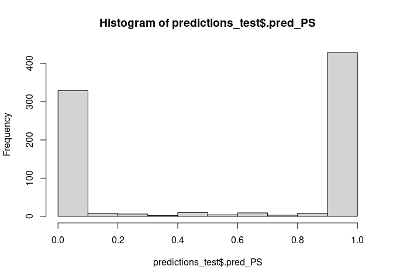

```r
hist(predictions_test$.pred_PS, breaks = (0:10)/10)
```

There are almost no cells with moderate probability estimates. Furthermore, when the model is incorrect, it is “confidently incorrect”.

The probably package has tools for visualizing and correcting models with poor calibration properties.

The most common plot is to break the predictions into about ten equally sized buckets and compute the actual event rate within each. For example, if a bin captures the samples predicted to be poorly segmented with probabilities between 20% and 30%, we should expect about a 25% event rate (i.e., the bin midpoint) within that partition. Here are plots with ten and five bins:

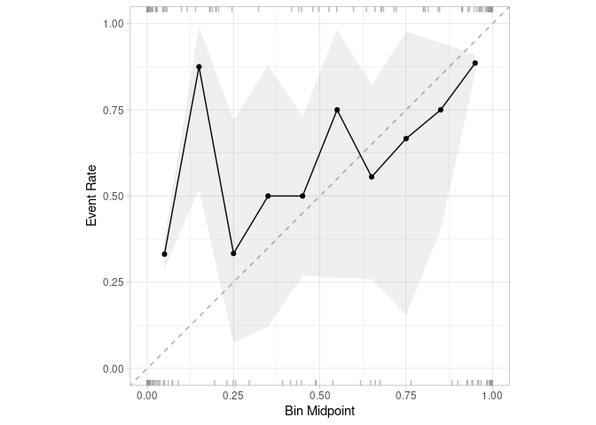

```r
cal_plot_breaks(predictions_test, truth = class, num_breaks = 10)
```

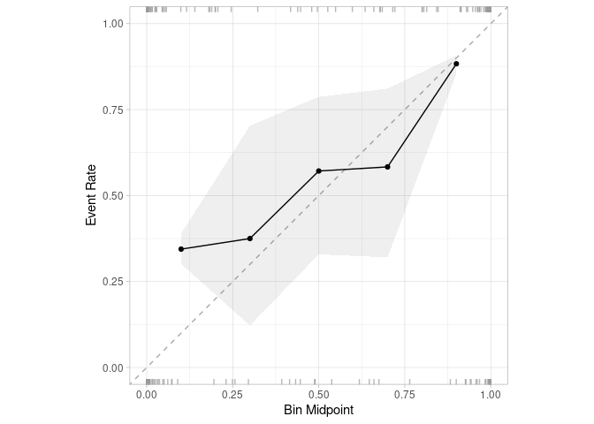

```r
cal_plot_breaks(predictions_test, truth = class, num_breaks = 5)
```

The probabilities are not showing very good accuracy.

## Remediation: Calibrating the classifier

The good news is that we can do something about this. There are tools to “fix” the probability estimates so that they have better properties, such as falling along the diagonal lines in the diagnostic plots shown above. Different methods improve the predictions in different ways.

## Platt scaling (logistic calibration)

The most common approach is Platt scaling, also called logistic calibration. This works in the following way: The original model is used to predict on the validation data set, returning predicted probabilities. We already know these probabilities are off, i.e., not well-calibrated. Then, we fit a simple logistic regression model, using the predicted probabilities from the original model as “x/feature” and the true labels as “y/target”. In this way, we stack a second model on top of the first one: Original Model -> Probabilities -> Logistic Regression Model -> Calibrated Probabilities.

If effect, the logistic regression model estimates the probability regions where the original model is off (as shown in the diagnostic plot). For example, suppose that when the model predicts a 2% event rate, the logistic regression model estimates that it under-predicts the probability by 5% (relative to the observed data). Given this gap, new predictions are adjusted up so that the probability estimates are more in-line with the data.

### With Base R:

Let’s do this with base R first:

```r
# Create predictions on the validation set
predictions_val <- nb_fit %>%
  predict(cells_val, type = "prob") %>%
  select(.pred_PS) %>%
  bind_cols(cells_val)

# For model fitting, transform class (a factor) to binary (0-1)
predictions_val$class <- abs(as.numeric(predictions_val$class) - 2)

# Fit a logistic regression with y = true label of validation set and x = predictions on validation set
calibrator_logreg <- glm(class ~ .pred_PS, family = binomial, data = predictions_val)
```

How do we know if this works? As we used training data to fit the Naive Bayes model and validation data to fit the logistic regression model, we need to use testing data to assess the performance of the combined (and hopefully well-calibrated) model:

```r
# Use logistic calibration model to adjust predictions on test data
predictions_test_calibrated <- predictions_test
predictions_test_calibrated$.pred_PS <- predict(calibrator_logreg, newdata = predictions_test_calibrated, type = "response")
```

How well-calibrated is this model?

```r
roc_auc(predictions_test_calibrated, truth = class, .pred_PS)
```

```
## # A tibble: 1 × 3
##   .metric .estimator .estimate
##   <chr>   <chr>          <dbl>
## 1 roc_auc binary         0.856
```

```r
brier_class(predictions_test_calibrated, class, .pred_PS)
```

```
## # A tibble: 1 × 3
##   .metric     .estimator .estimate
##   <chr>       <chr>          <dbl>
## 1 brier_class binary         0.160
```

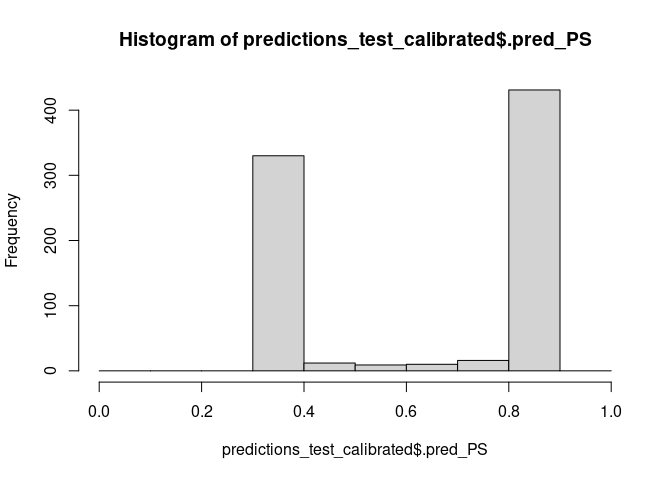

```r
hist(predictions_test_calibrated$.pred_PS, breaks = (0:10)/10)
```

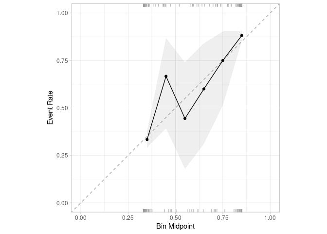

```r
cal_plot_breaks(predictions_test_calibrated, truth = class, num_breaks = 10)
```

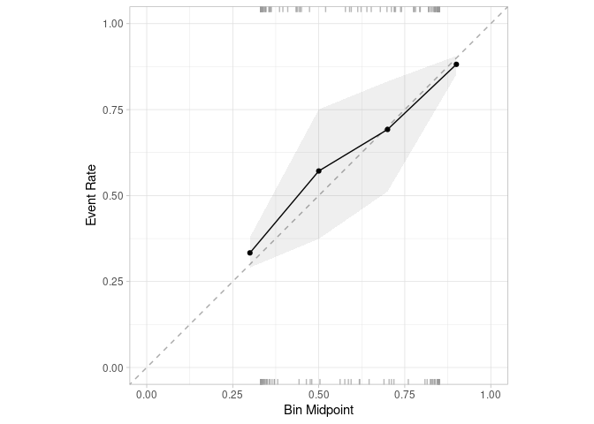

```r
cal_plot_breaks(predictions_test_calibrated, truth = class, num_breaks = 5)
```

We can see a slight improvement: The brier score as evaluated on the test data improved. Interestingly, the AUC remains unaffected. This should be no surprise, however, as the AUC assesses a model’s ability to discriminate between classes. If we simply squash the probabilities using the logistic function, this will likely not change the predicted labels too much.

### With probably:

```r
# Make predictions on the validation set (again because probably wants a factor as target)
predictions_val <- nb_fit %>%
  predict(cells_val, type = "prob") %>%
  bind_cols(cells_val)

# Calibrate the model using validation data
calibrator_logreg_alt = cal_estimate_logistic(predictions_val, truth = class)

# Predict with original model on test data
predictions_test <- nb_fit %>%
  predict(cells_test, type = "prob") %>%
  bind_cols(cells_test)

# Apply calibration model on original model predictions
predictions_test_calibrated_alt <- cal_apply(predictions_test, calibrator_logreg_alt)
```

As a sanity check, we should get score the same metrics as by using base R:

```r
roc_auc(predictions_test_calibrated_alt, truth = class, .pred_PS)
```

```
## # A tibble: 1 × 3
##   .metric .estimator .estimate
##   <chr>   <chr>          <dbl>
## 1 roc_auc binary         0.856
```

```r
brier_class(predictions_test_calibrated_alt, class, .pred_PS)
```

```
## # A tibble: 1 × 3
##   .metric     .estimator .estimate
##   <chr>       <chr>          <dbl>
## 1 brier_class binary         0.160
```

## Isotonic regression

A different approach is to use isotonic regression. This method can result in very few unique probability estimates. The `probably` package has a version of isotonic regression that resamples the process to produce more unique probabilities:

```r
# Calibrate the model using validation data
calibrator_iso = cal_estimate_isotonic(predictions_val, truth = class)

# Apply calibration model on original model predictions
predictions_test_calibrated_iso <- cal_apply(predictions_test, calibrator_iso)
```

Do we improve the calibration in comparison to Platt scaling?

```r
roc_auc(predictions_test_calibrated_iso, truth = class, .pred_PS)
```

```
## # A tibble: 1 × 3
##   .metric .estimator .estimate
##   <chr>   <chr>          <dbl>
## 1 roc_auc binary         0.849
```

```r
brier_class(predictions_test_calibrated_iso, class, .pred_PS)
```

```
## # A tibble: 1 × 3
##   .metric     .estimator .estimate
##   <chr>       <chr>          <dbl>
## 1 brier_class binary         0.166
```

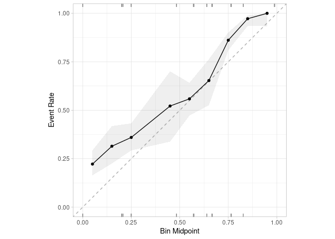

```r
cal_plot_breaks(predictions_test_calibrated_iso, truth = class, num_breaks = 10)
```

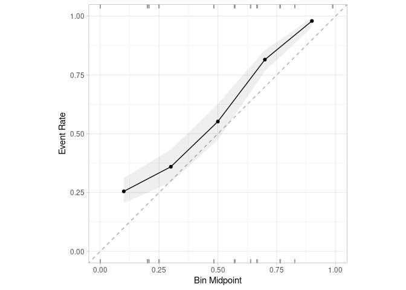

```r
cal_plot_breaks(predictions_test_calibrated_iso, truth = class, num_breaks = 5)
```

No, it seems like isotonic regression can achieve similar calibration performance here, but not improve further than what Platt scaling has achieved.

# Summary

In this exercise sheet we learned how to fit a classification model on a training task and how to assess its performance on unseen test data with the help of `tidymodels`. We showed how to split data manually into training and test data, and use `probably` to assess if a model is calibrated. We discussed how Platt scaling/logistic calibration and isotonic regression can be used to improve calibration (although not perfectly calibrate the model here). Also note that in a real-world scenario, we would have wanted to refit the Naive Bayes classifier on the combined train-validate data once we have calibrated it, to mirror nested resampling and reduce bias.